# Assignment 4

Dakota Hawkins

2/22/2022

# Welcome to Assignment 4

### Before we begin

Unlike Assignments 1-3, you will no longer be provided with the RMarkdown code. All of the code blocks here are empty and accompanied by instructions for what is expected in the code block. Do not neglect your `main.R` skeleton file as the functions there will constitute most of the points you earn.

*THE BULK OF YOUR GRADE WILL BE ON YOUR WORK IN `main.R`*

Anything that is specified to occur in functions you create MUST be in the `main.R` file. While you theoretically CAN do some or all of the homework in this .Rmd file, it is bad practice to have your behind-the-scenes ‘backend’ coding in the same files as your user-facing ‘frontend’ report. Your `report.html` may be referenced to visually check any graphical outputs you may generate for this and all future assignments, but your `main.R` functions will be run outside of their respective markdown environments.

## 1. Reading and filtering count data

To begin, let’s read the raw count matrix, named `verse_counts.tsv`, and filter out all zero-variance genes. Filtering out zero-variance genes is necessary for several common analysis steps, such as Principal Component Analysis (PCA), and can be helpful to reduce the size of our dataset if memory issues are a constraint. Implement the `filter_zero_var_genes` function in `HW5.R` to remove zero variance genes from the count matrix, and return a list containing both the name of the returned genes, and the counts of each gene for every sample.

## 2. Constructing sample meta data from sample names

Often during analysis, it’s beneficial to separate data modes from each other ( i.e. to have one data frame containing gene expression data, and separate data frame for any gene or subject level information). Here we’ll construct a `tibble` from sample names located in the columns of our count matrix. Implement the `meta_info_from_labels` function to extract the sample name, timepoint, and replicate number from each sample name. The function should then return a `tibble` with all the relevant information.

## 3. Count distributions and normalization

Often we will want to normalize gene counts between samples so that comparisons are more reliable. Given read counts are a relative measure of abundance, normalization is a necessary step during RNAseq analysis when samples may have differing numbers of total reads.

### 3a. Visualizing count distributions via boxplots

To visualize these differences, implement the `plot_sample_distributions()` function using `ggplot2` to create boxplots visualizing the read counts for each sample over all genes. Ensure the function is able to scale the y-axis to $log$ values if specified by the `scale_y_axis` parameter. Color each boxplot by its respective sample name.

*Hint*: Reshape your count matrix from a *wide* format, to a *long* format.

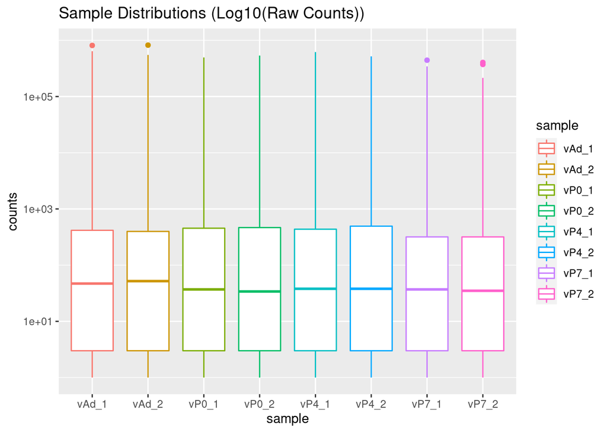

### 3b. Count variance vs mean count

Another aspect of RNAseq data that often needs to be accounted for the is relationship between variance and mean expression: that is, more highly expressed genes will exhibit higher variance values. This is problematic as interesting patterns controlled by genes at naturally lower expression values will be washed out by more highly expressed genes. To visualize this phenomenon, implement the `plot_variance_vs_mean()` function to plot gene variance on the y-axis vs mean count rank on the x-axis, where with $p$ genes, the most highly expressed gene will have rank $p$ and the most lowly expressed gene will have rank $1$.

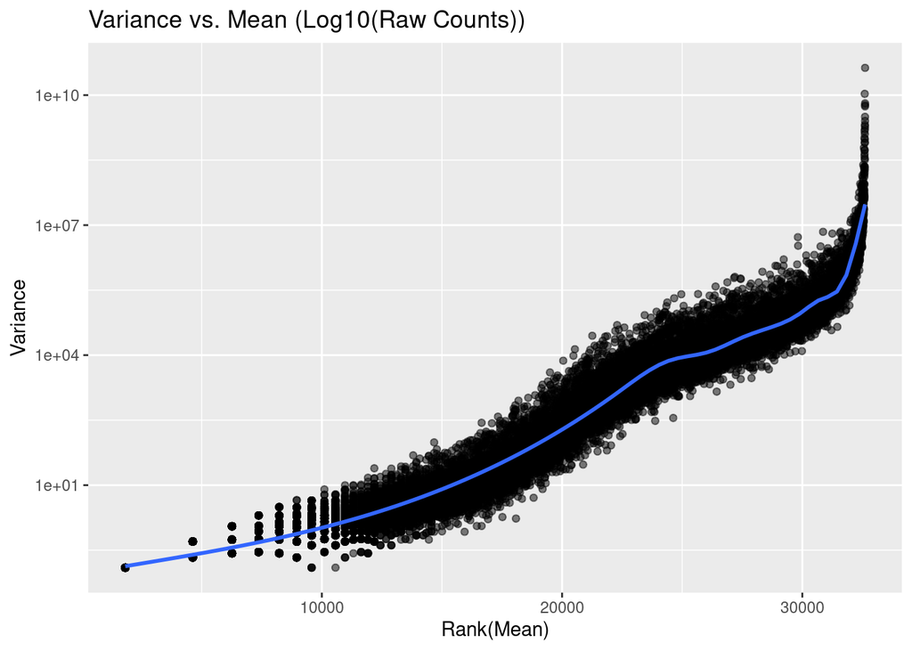

### 3c. Visualizing patterns with PCA

*Hint*: pay close attention to the `prcomp` documentation for running PCA, and ensure you’re providing the count matrix in the correct orientation for running PCA over the *samples*.

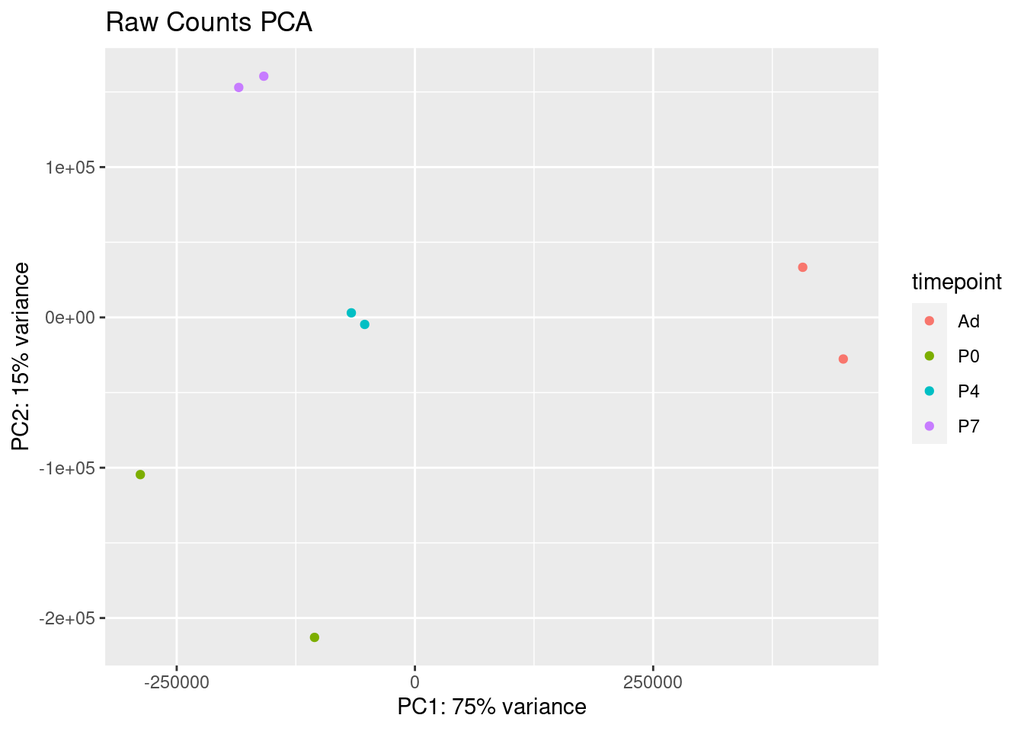

## 4. Normalizing with counts per million

Now that we’ve explored our dataset prior to count normalization, we should normalize our data to see how things change. A simple and intuitive approach to count normalization is *counts per million*: that is finding the number of counts for a given gene in a given sample for each million reads observed. It can be easily calculated using this formula

$cpm = \frac{X_{i, j}}{\sum \limits_{i=1}^P X_{i, j}} \cdot 10^6$

Where $X$ is a $P \times N$ count matrix with genes as rows and samples as columns.

### 4a. CPM matrix calculation

Implement the `normalize_by_cpm` function to normalize a raw count matrix given the provided formula. Often we will want to work with log-transformed counts as they are useful for stabilizing variances and possibly fitting assumed statistical distributions for common tests. After calculating the CPM matrix, ensure the returned matrix is `log2` transformed.

### 4b. Visualizing CPM

Visualize the effect of CPM normalization on the dataset by visualizing the sample distributions, the relationship between variance and average expression values, and plotting the samples along the first two PCs. Does the normalization seem effective? What, if any, are the major differences observed between the plots produced by raw counts?

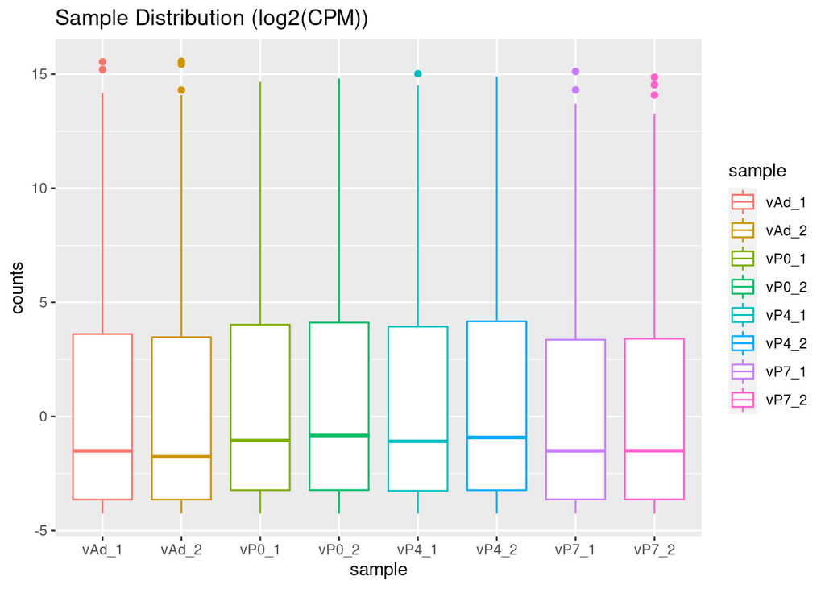

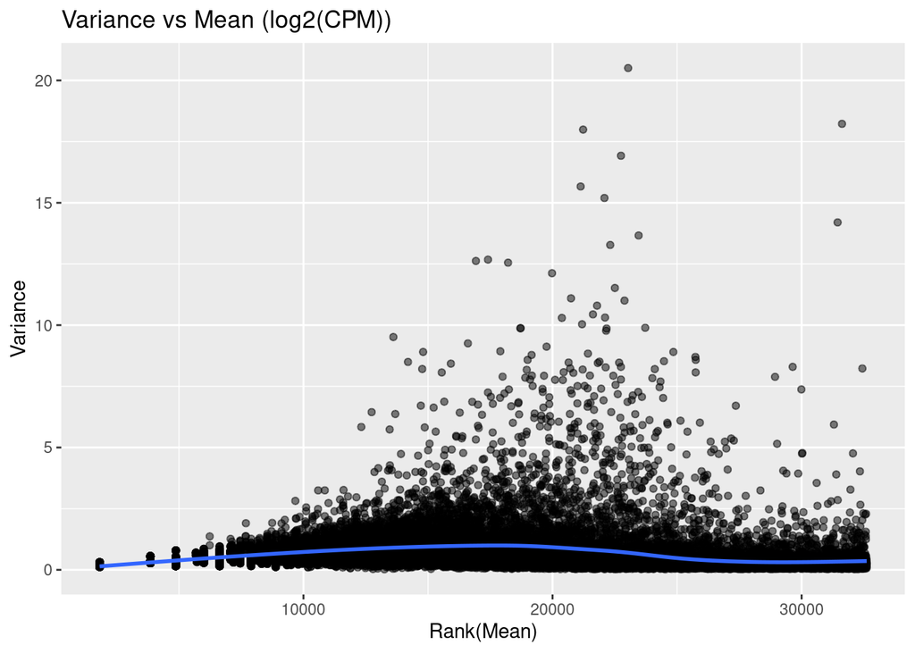

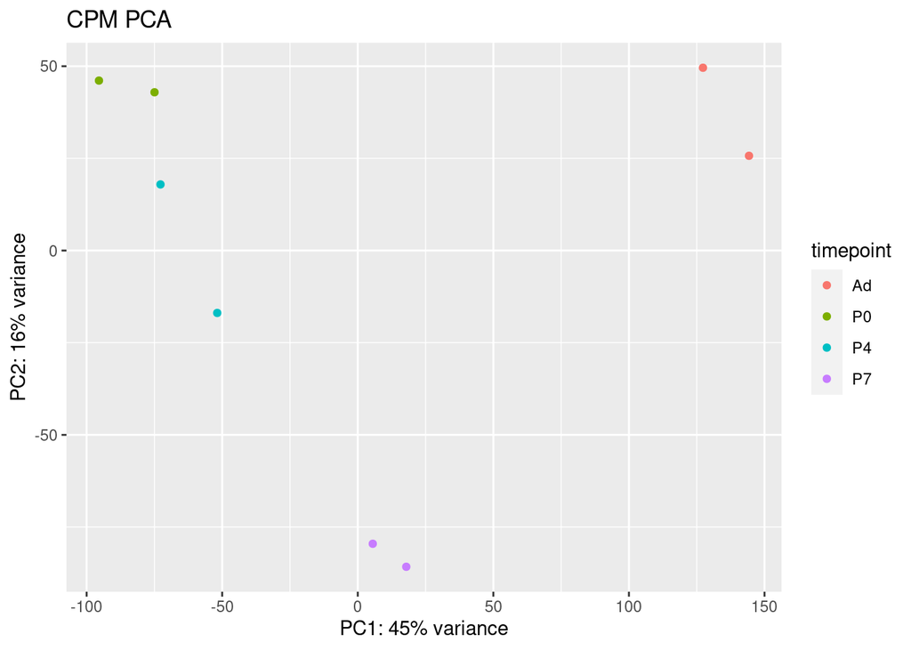

## 5. Normalizing with DESeq2

DESeq2 is a common and prolific tool for performing differential expression analysis (DEA) in RNAseq data. Within that process, DESeq2 implements its own normalization procedure prior to performing DEA for more reliably identified differential genes. You can read more about it [here](http://bioconductor.org/packages/devel/bioc/vignettes/DESeq2/inst/doc/DESeq2.html#data-transformations-and-visualization).

### 5a. Variance stabilized counts with DESeq2

To normalize our data with DESeq2, implement the `deseq_normalize()` function to extract the variance stabilized counts. Unlike CPM normalization, DESeq directly considers the comparison of interest (in our case `timepoint`), so ensure you are both appropriately passing the sample metadata to the `deseq_normalize` function as well as a formula describing the comparison of interest.

*Hint*: the previously link DESeq2 documention explicity describes how to set up and calculate normalized values. For our case, we are interested in the counts generated using the `DESeq2::vst` function.

### 5b. Visualizing DESeq2 Normalizion

Visualize the effect of DESeq2 normalization on the dataset by visualizing the sample distributions, the relationship between variance and average expression values, and plotting the samples along the first two PCs. How does DESeq2 normalization compare to CPM? Raw values? Which method, if any, seems most effective?

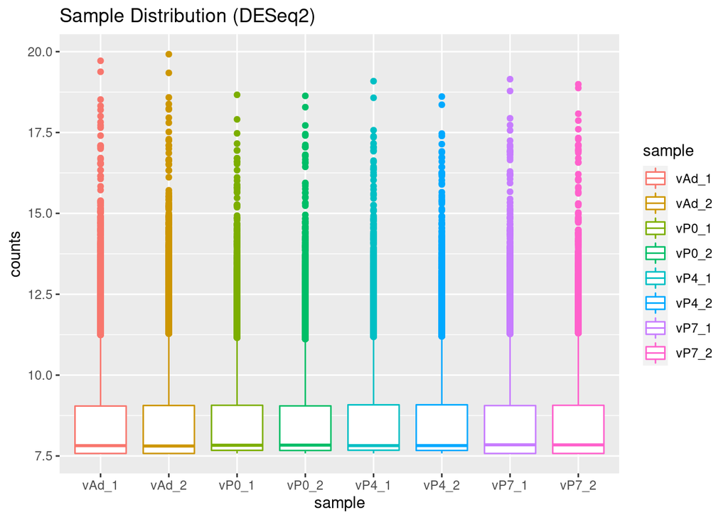

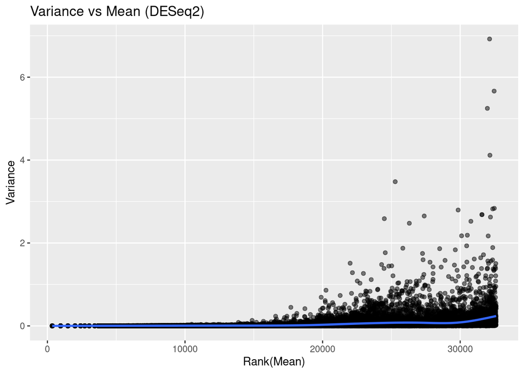

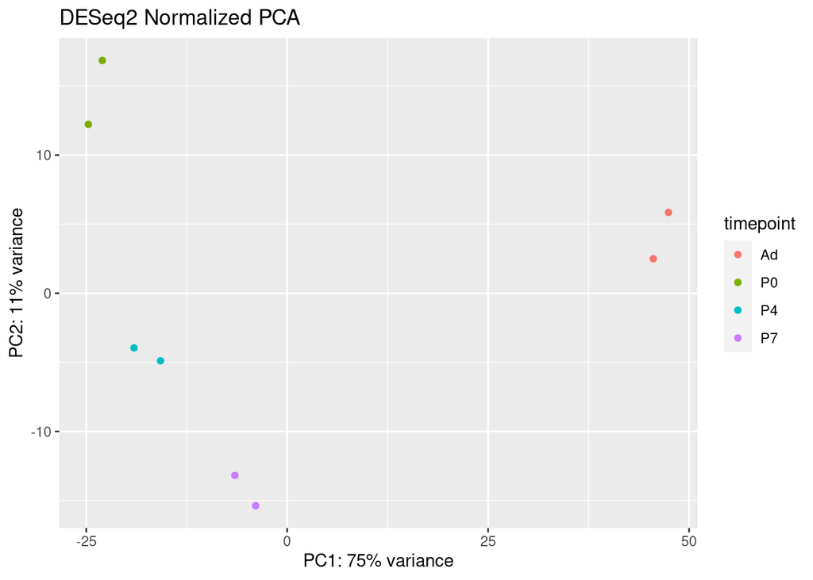